# Building a Natural Language Next-Word Prediction Model

Data exploration, model architecture, performance debugging, and a shipped product

Martin Okwumuo I.

2026

# Case Study

## Summary

This project builds a working next-word prediction engine; the same category of “invisible AI” behind phone keyboards, search auto-complete, and drafting assistants entirely from raw text, with no external APIs or pre-trained language models. It covers the full life-cycle of a real data science project; exploratory analysis on a 4.4-million lines, 572-million character corpus; a statistically grounded model architecture; several rounds of serious performance debugging when the initial build stopped scaling; a rigorous held-out evaluation; and a shipped, non-technical-friendly Shiny application.

The headline result: **17.5% Top-1 accuracy and 33.7% Top-5 accuracy on data the model never saw during training, roughly 2.5–3x better than a naive baseline**. This was reached after diagnosing and fixing two separate performance bugs that had brought earlier builds to a standstill.

## The Problem

Predicting the next word someone is about to type sounds simple, but it sits on a genuinely hard statistical problem. Natural language is enormous in its combinations and heavily skewed. A handful of words account for a large share of usage, while the long tail of the vocabulary is vast and sparse. A good solution has to be accurate and fast enough to feel instant, on hardware far smaller than what powers a commercial keyboard app.

## The Algorithm

An **n-gram language model with ‘Stupid Backoff’** (Brants et al., 2007); the same class of technique Google used for early web-scale language models, built on a corpus of real news, blog, and Twitter(X) text.

## Design Methodology

The **Exploratory Data Analysis** (full report available separately) features a finding that shaped nearly every downstream engineering decision. In a diagnostic sample of the corpus, 91.4% of all trigrams occurred exactly once. That single statistic is the reason the model: 1. Drops singleton n-grams before training even completes (`MIN_FREQ_TRIGRAM/FOURGRAM = 2`). Keeping them would mean storing a huge table carrying almost no generalizable signal. 2. Keeps only the top-K most likely continuations per context, bounding table size independent of how much of the corpus is used for training 3. Backs off through five levels; 5-gram — 4-gram - trigram - bigram - unigram rather than relying on any single order, since exact long-context matches are the exception, not the rule

This is the difference between a model that merely fits the training data and one that’s been designed around how that data actually behaves.

## Engineering Challenges

The most instructive part of this project wasn’t the first working version, it was diagnosing why later. Larger-scale runs silently stopped completing. Two separate issues surfaced, each requiring a different kind of debugging instinct.

### Issue 1 — A silent encoding bottleneck

After scaling training up to a real fraction of the corpus, a pre-processing step that had run fine on a small sample simply never finished. The cause wasn’t the regex logic itself, it was that the raw Twitter file contains invalid UTF-8 byte sequences (common in real-world social media text), and `skipNul = TRUE` at read time only strips null bytes, not invalid encoding. Every downstream regex call was silently paying a per-string encoding-repair cost, across millions of lines, on every single pass.

**The Fix:** Validate and repair encoding once, up front, before any regex touches the text, removing that repeated cost entirely and add chunked processing with progress output, so a genuinely slow step and a hung one are never indistinguishable again.

```r
# Before: every regex call below pays an encoding-repair cost, silently,
# for every affected string, every time.
text <- stri_replace_all_regex(text, "\\s+", " ")

# After: fixed once, up front.
all_text <- stri_enc_toutf8(all_text, validate = TRUE)
```

### Issue 2 — Quadratic cost hiding inside a evaluation loop

A separate hang appeared later, in the held-out evaluation script. The root cause: for every position in every held-out line, the script built its prediction context by pasting together the entire preceding text of that line, not just the last few words the model actually uses. For a single 500-word blog post, that’s on the order of a quarter-million word-concatenations, for one line, before evaluation had even started scoring anything.

**The Fix:** cap context construction at exactly what the model uses (the last 4 tokens), generated with the same vectorized sliding-window technique used to build the model itself, turning an unbounded, per-line R loop into a handful of fast, whole-corpus data.table operations.

Both fixes reflect the same underlying discipline; “when something that should be fast isn’t, look for hidden per-item costs that scale with the wrong variable,” not just “add more compute.”

## Evaluation

A held-out split (2% of the full corpus) was carved off before any training sampling occurred, so the model was scored only on text it genuinely never saw. Evaluation itself was rebuilt to run as batched data.table joins rather than one function call per test case; the same class of fix as Issue 2 above, applied to the scoring methodology itself.

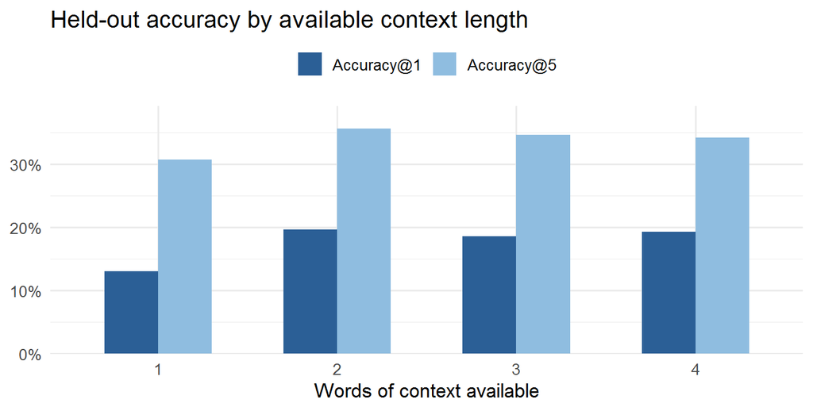

| Metric | Result |
| --- | --- |
| Accuracy@1 | 17.5% |
| Accuracy@3 | 28.3% |
| Accuracy@5 | 33.7% |
| MRR | 0.234 |

*(vs. ~5–7% Accuracy@1 for a naive “always guess the most common word” baseline)*

The accuracy-by-context-length breakdown is, on its own, a small piece of evidence-based diagnosis. Accuracy climbs sharply from one to two words of context, then flattens rather than climbing further, the exact fingerprint of the data sparsity identified during the original EDA, now confirmed at evaluation time. It’s also the clearest, most concrete argument for the highest-leverage next step: more training data, not a different architecture.

## Data Product (App)

A working model isn’t a finished project without something a real person can use. The Shiny application built on top of this engine was deliberately redesigned around one constraint: It should be usable at a glance by someone with zero technical background.

[interactive chart not shown]

[View App in Full Mode](https://snndvl-martin-okwumuo.shinyapps.io/Text-Prediction-Model)

[View GitHub Repository](https://github.com/okwumuo-martin/Text-Prediction-Model)

Concretely, that meant:

- Suggestions render as **tappable chips**, not a raw prediction table, tapping one appends the word and immediately shows new suggestions, mirroring the interaction a phone’s keyboard already trained everyone to expect.
- Plain-language copy up top, with the technical detail (model type, training data) present but pushed to a small footer rather than competing for attention
- A one-tap example phrase, so a first-time viewer never has to think of something to type before seeing the product work

The same prediction engine also powers a live, embedded demo inside the project’s own pitch presentation, the same code path, running interactively, in front of whoever’s evaluating the work.

## Skills Demonstrated

- **Data Science Fundamentals** — exploratory analysis, vocabulary/frequency distribution analysis, n-gram sparsity diagnosis, held-out evaluation design.
- **Applied NLP** — n-gram language modeling, Stupid Backoff, text preprocessing and tokenization at scale.
- **Performance Engineering** — diagnosing and fixing two distinct classes of scaling bugs (encoding overhead, quadratic algorithmic cost), integer-encoding a pipeline for large-scale `data.table` grouping.
- **Rigorous Evaluation Methodology** — leakage-free held-out splits, vectorized batch scoring, honest baseline comparison.
- **Product Thinking** — redesigning a functional demo into something a non-technical stakeholder can understand and use unassisted.
- **R Engineering** — `data.table`, `stringi`, `shiny`, reproducible R Markdown reporting throughout.

## Moving further

The evaluation results point to a specific, evidence-backed roadmap rather than a vague “make it better”:

1. **Scale up training data** — the flattening accuracy curve past two tokens of context is a sparsity signature the current 20% training sample explains well; more data is the most direct lever available.
2. **Quantify backoff level usage explicitly** — instrument how often each order (4-gram vs. trigram vs. bigram) actually fires in production, to target future training data where it moves accuracy the most.
3. **Ship it further** — the same engine already runs as a live Shiny app; the natural next step is packaging it behind a browser extension or messaging integration.

*Full technical details including the original exploratory data analysis, the model’s build and evaluation scripts is available alongside this case study.*